# Girl Power? Investment Trends for Female Entrepreneurs on Shark Tank (US)

Final Project  
Data Science 1 with R (STAT 301-1)

Author

Allison Kane

Published

December 5, 2023

**Github Repo Link**

[Allison Kane Final Project Repo Link](https://github.com/stat301-1-2023-fall/final-project-1-akane2460.git)

## Demographics

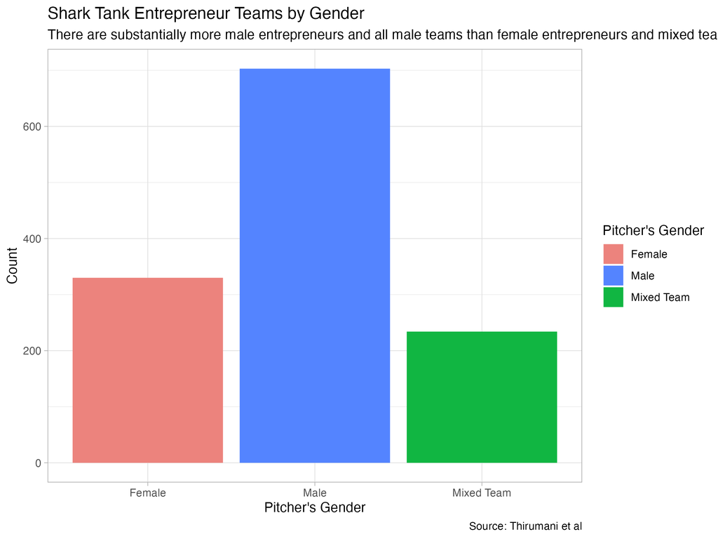

Gender Ratios

Women are often underrepresented in positions of authority, especially as entrepreneurs. In Shark Tank (US) seasons 1-14, it is clear that women-led businesses are outnumbered by male-led businesses. Mixed gender entrepreneur teams are represented even less. This gender imbalance might limit viewers’ exposure to female entrepreneurs and hinder their acceptance of women in positions of power, especially in business.

Often, women find entering specific, male-dominated fields more difficult. Additionally, industries with greater representations of women are often viewed as less lucrative, less serious and less deserving of investment.

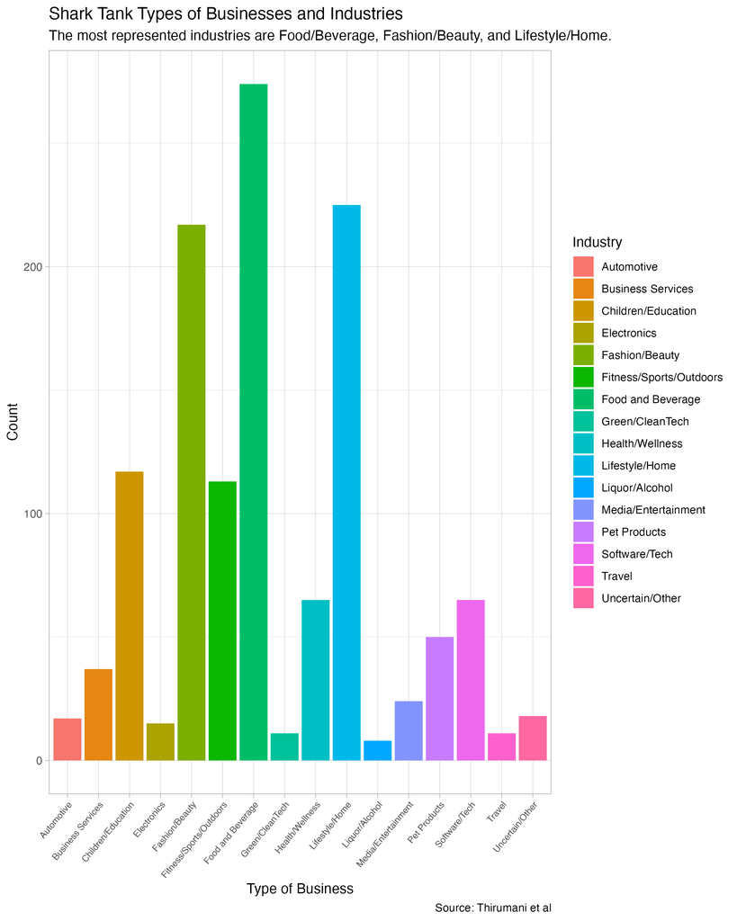

Businesses Represented

In shark tank (US) seasons 1-14, the industries most represented include Food/Beverage, Fashion/Beauty, and Lifestyle/Home. Some of these businesses are typically associated with women, like Fashion/Beauty, but representation in leadership roles is rarely dominated by women.

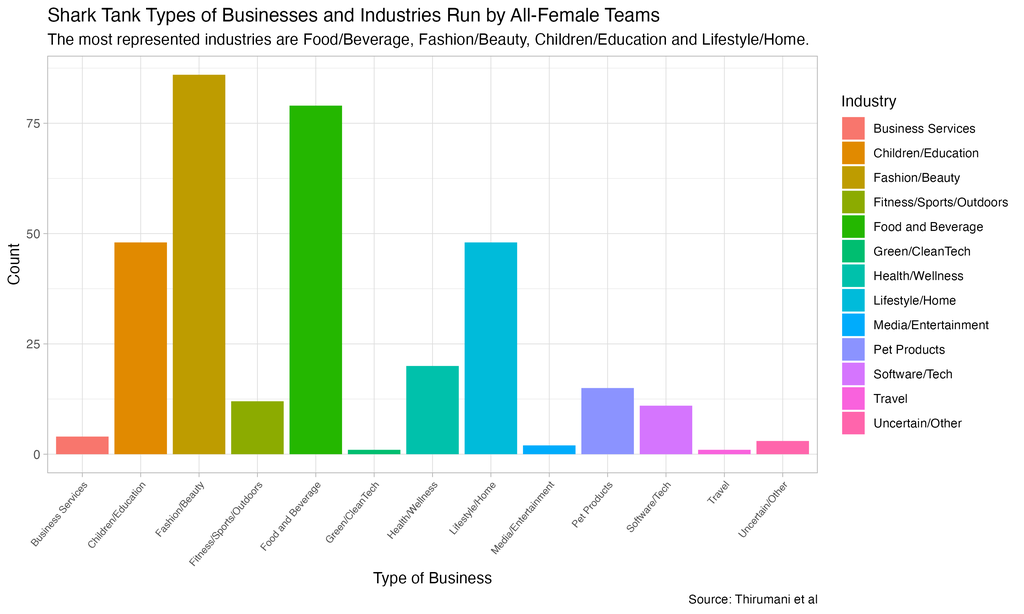

Industries Represented with Female Entrepreneurs

Industries with female entrepreneurs represented on shark tank (US) seasons 1-14 show that women are most involved in Food/Beverage, Fashion/Beauty, Children/Education and Lifestyle/Home industries. Three industries do not have *any* female-run businesses represented: Automotive, Electronics, Liquor/Alcohol.

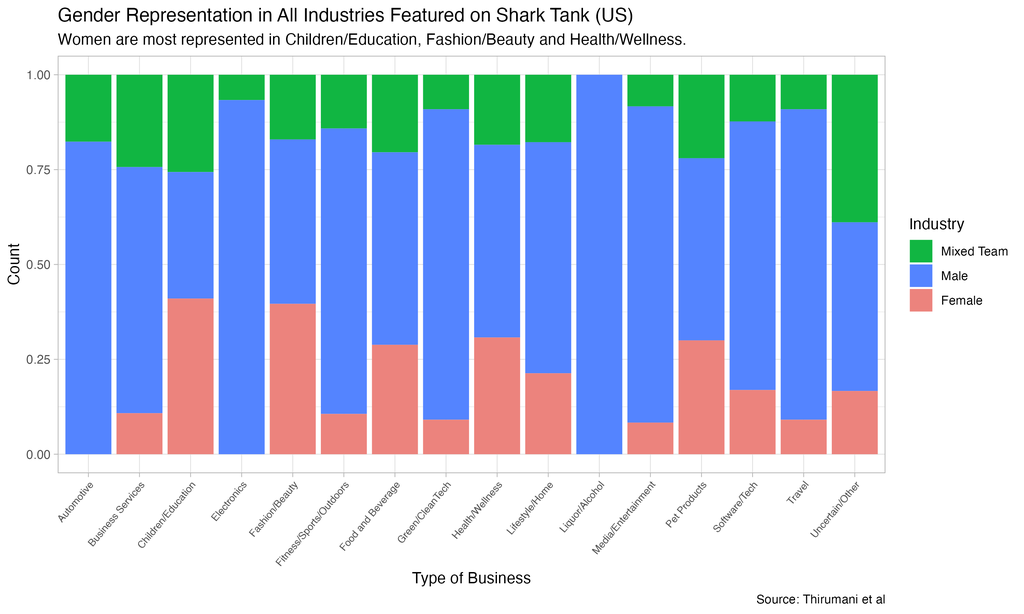

Industry Leadership Gender Representation

Further analysis indicates that only one industry on Shark Tank (US) has more female-led businesses represented than male or mixed team led businesses: children/education. All other industries have a greater representation of male entrepreneurs than female entrepeneurs and mixed teams. Representation of female entrepeneurs is better in Fashion/Beauty, Health/Wellness and Pet Products industries, but male-entrepeneurs are still represented more often. Representation of female entrepreneurs is the worst in the Automotive, Electronics and Liquor/Alcohol industries. In particular, Liquor/Alcohol does not have any female-led or mixed-team led businesses represented at all.

The bias in gender-representation in Shark Tank (US) could have additional effects, including how frequently deals are made for different genders, the quality of the deal, and how individual sharks behave towards different genders of entrepeneurs.

## General Deal Trends

### Deal Frequency

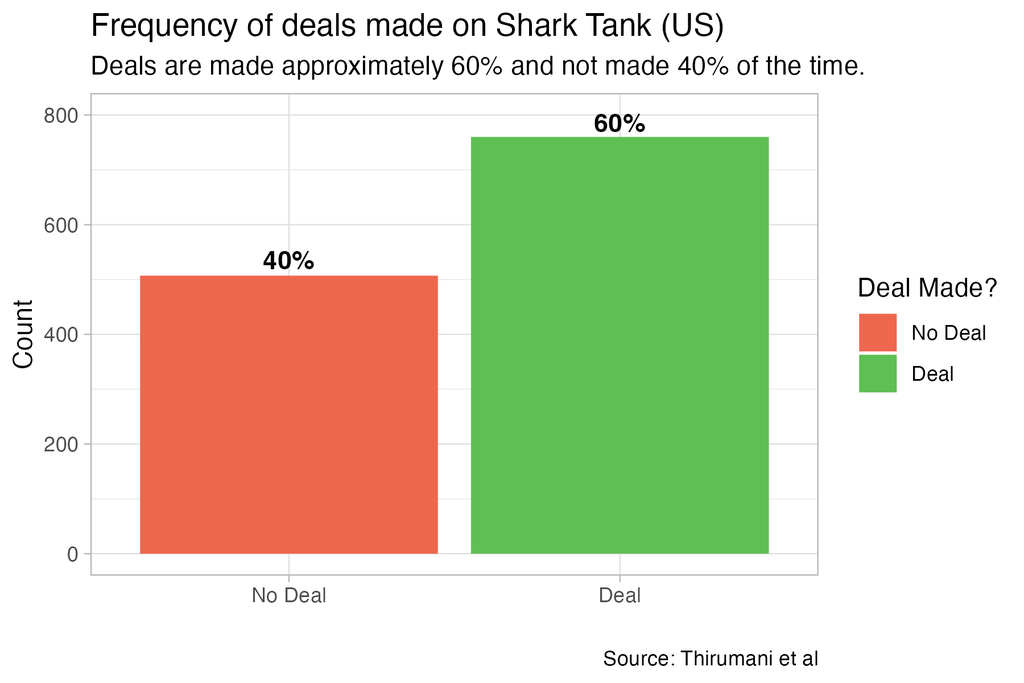

Frequency of Deals Made

Generally, on Shark Tank (US), deals are made in about 60% of pitches from Season 1-14. However, this frequency of deals made might change based on gender.

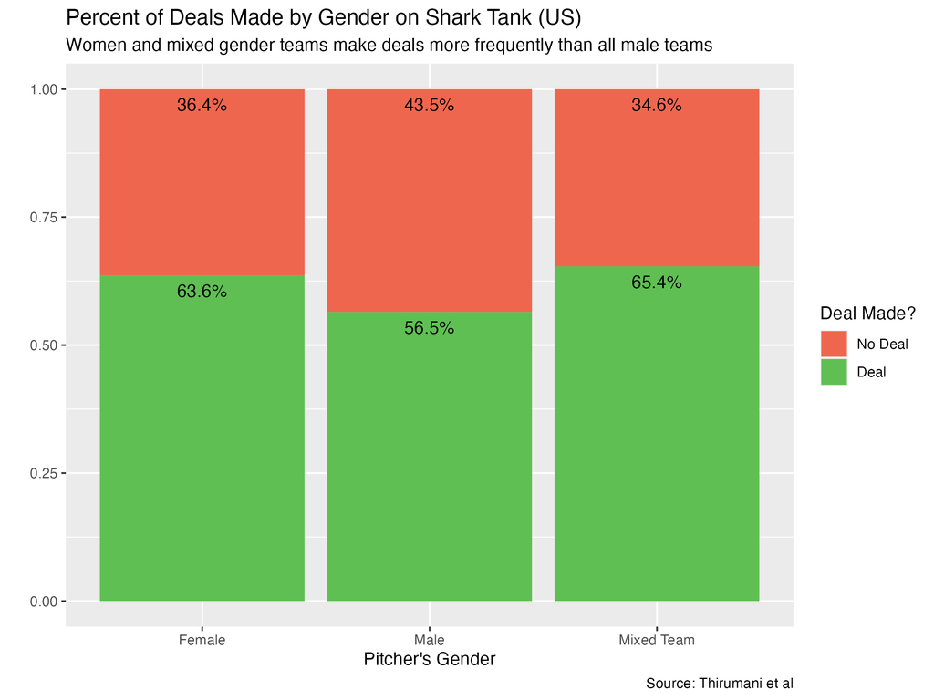

When examining how often deals are made by gender, female entrepreneurs receive deals *more* often than their male counterparts, approximately 64% and 57% of the time respectively. Mixed gender entrepreneur teams actually make deals more than both female and male entrepreneurs (65% of the time). This imbalance in number of deals made might reflect that women-led and mixed-team led businesses are simply underrepresented on Shark Tank. Since male-led teams are represented more often, they might be more likely to be rejected, lowering their ratio of successful to unsuccessful pitches. This higher rejection rate for male entrepreneurs might also reflect different deal-making strategies that are to be explored further.

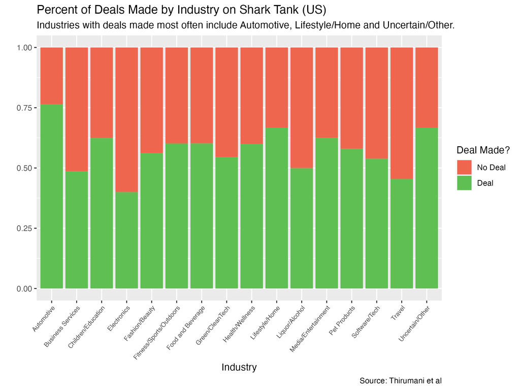

Automotive, Lifestyle/Home and Uncertain/Other industries seem to make deals most often, making deals 77%, 67% and 67% of the time. One of these industries–Lifestyle/Home–has a strong representation of female entrepreneurs. However, the Automotive industry lacks representation of any female entrepreneurs despite making deals the most often out of any industry.

### Requested Investment, Equity and Valuation

Before a deal is made on Shark Tank, entrepreneurs have to pitch their business and their requested investment, offered equity, and estimated valuation of their business.

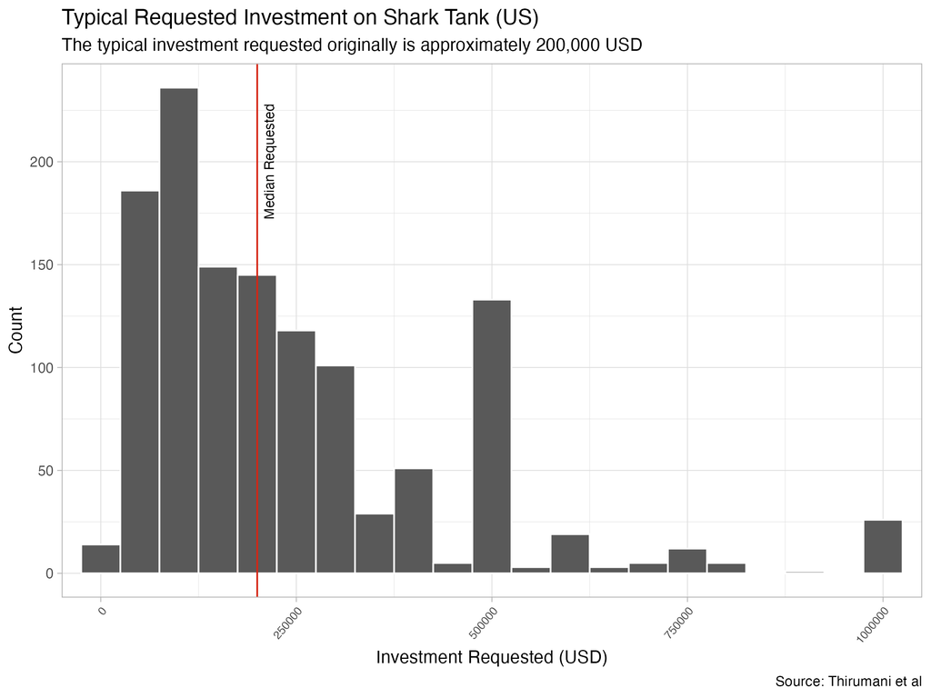

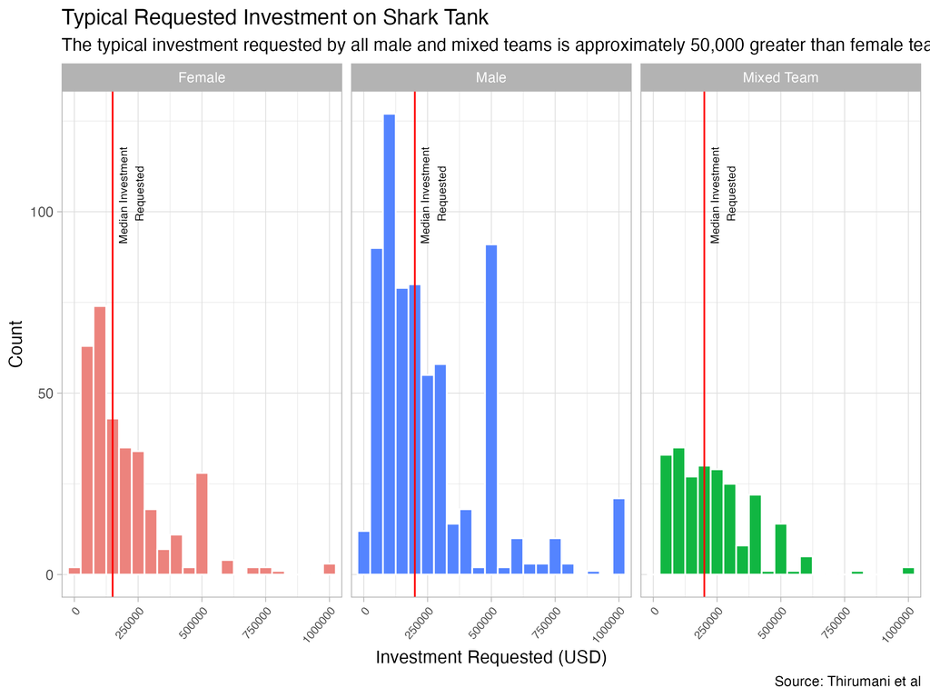

In analyzing how requested investment on Shark Tank (US) varies by gender, it is clear that male entrepreneurs and mixed gender entrepreneur teams typically request 50,000 USD more than their female entrepreneur counterparts. Female entrepreneurs also request 50,000 USD less than the general population. This difference in requested investment might be explained by different equities offered or different typical valuations of their businesses that are to be analyzed.

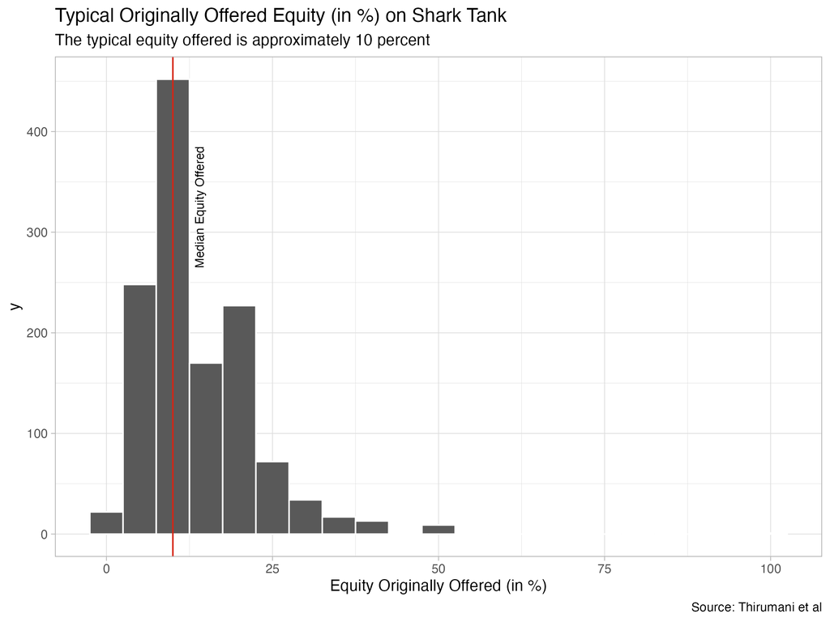

The typical offered equity during a pitch on Shark Tank (US) is approximately 10 percent. There is some slight variation, with the most offered being 100 percent (indicating the business owner would like to be bought out) and lease offered being 1 percent. The distribution of equity offered is skewed right, with a peak at approximately 10 percent. It is important to investigate, however, if this offered equity is uniform across all genders.

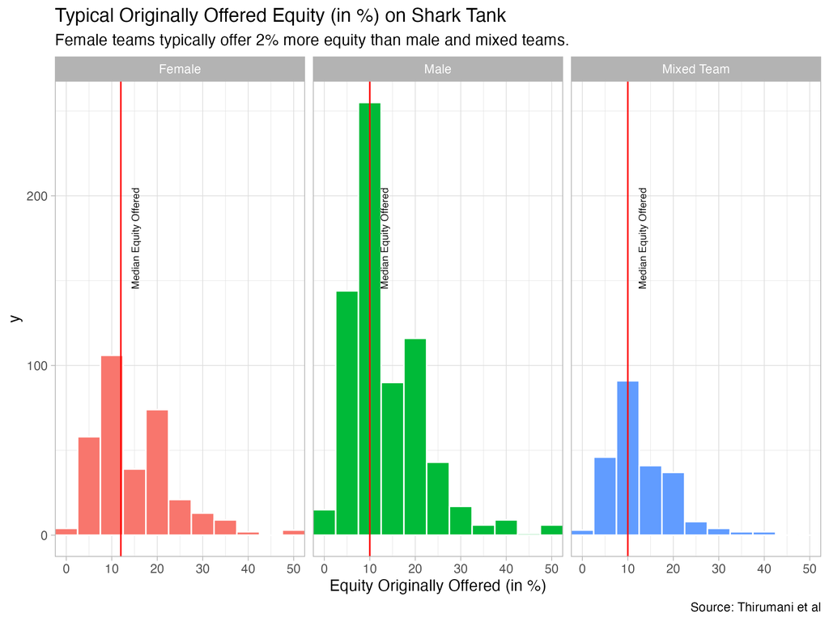

The typical offered equity during a pitch on Shark Tank (US) for female entrepreneurs is 12%, while the typical offered equity for both male and mixed gender entrepreneur teams is 10%. Female entrepreneurs typically offer 2% more in equity than both the general population and their male and mixed gender entrepreneur counterparts. The general distribution of offered equity appears to be the same across all genders, with a peak around the median equity offered and a slight right skew. Given that female entrepreneurs both offer more equity and request less in investment, it is likely that they undervalue their businesses compared to male and mixed team entrepreneurs.

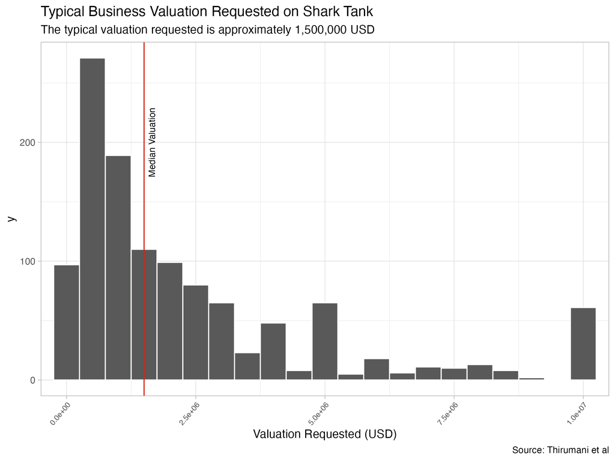

The typical initial valuation requested on Shark Tank is approximately 1,500,000 USD. The distribution of the requested valuation is skewed somewhat right with a peak slightly below this typical valuation. The greatest valuation requested is approximately 100,000,000 USD, while the lowest is approximately 40,000 USD. Given the differences in requested investment and equity offered across entrepreneur gender, it is expected that this requested valuation should differ for female, male and mixed gender entrepreneur teams.

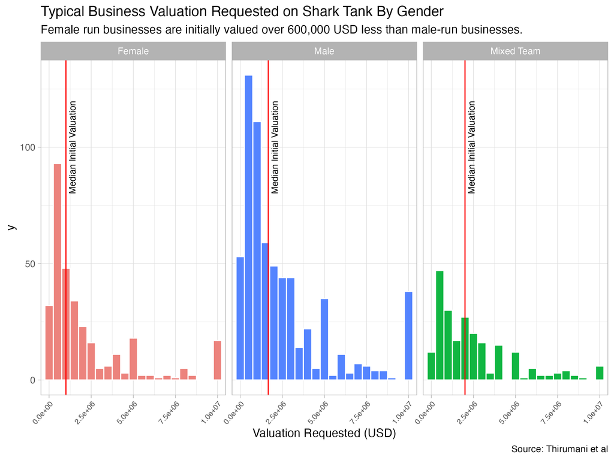

Businesses run by female entrepreneurs are valued typically at 1,000,000 USD, while male-run businesses are valued at 1,666,667 USD and mixed gender-run businesses are valued at 2,000,000 USD. The distributions of these businesses are similar, each with a right skew and a peak slightly below the median valuation. The range of valuations requested are somewhat similar, with male-run businesses having a lowest requested valuation value of 40,000 USD and highest of 100,000,000 USD. Female-run businesses have 85,714 USD and 25,000,000 USD respectively. Mixed-gender teams have 100,000 USD and 25,000,000 USD respectively.

### Received Investment, Equity and Valuation

The investment received after a deal on Shark Tank is a strong indicator of the success of a pitch on the show.

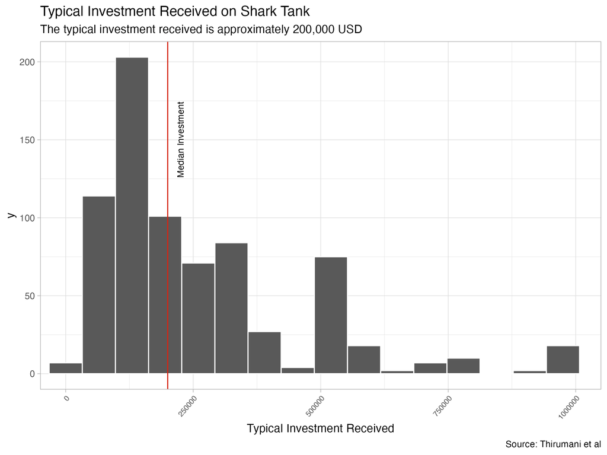

The typical investment for entrepreneurs that received deals on Shark Tank (US) is approximately 200,000 USD. The distribution of this typical investment is skewed somewhat to the right, with a peak slightly below this typical value. The greatest investment received is approximately 5,000,000 USD and least investment received is approximately 10,000 USD.

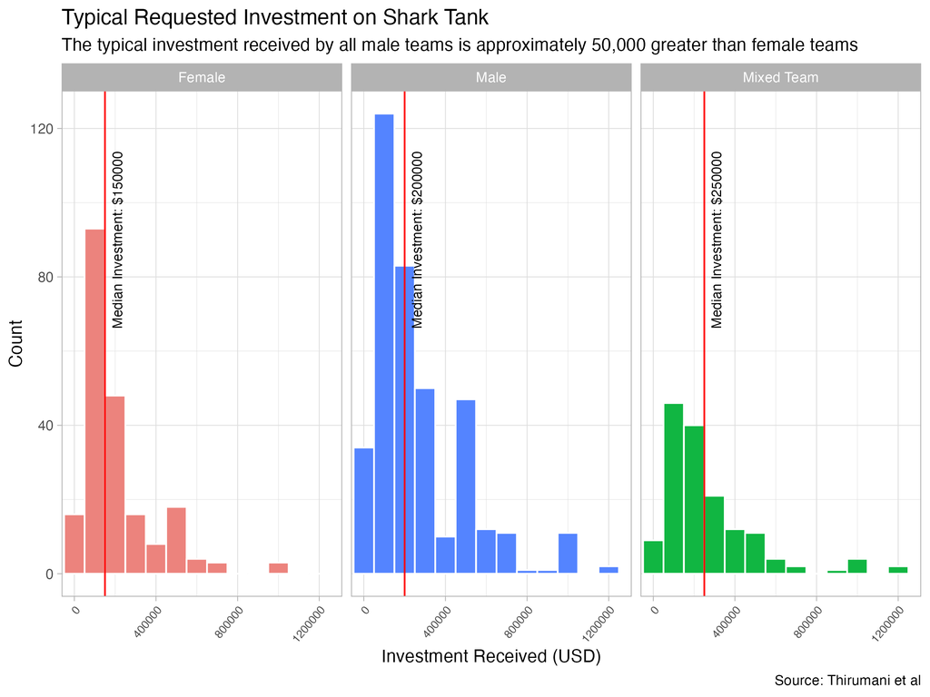

Typical investment for male entrepreneurs is approximately 50,000 USD more than for female entrepreneurs. Mixed gender entrepreneur teams receive a typical investment of 250,000 USD, greater than both female and male entrepreneurs. Female entrepreneurs receive typical investments 50,000 USD less than the general population. The distribution of the typical investments are similar across genders. Is this an instance where female entrepreurs give less equity or have lower business valuations?

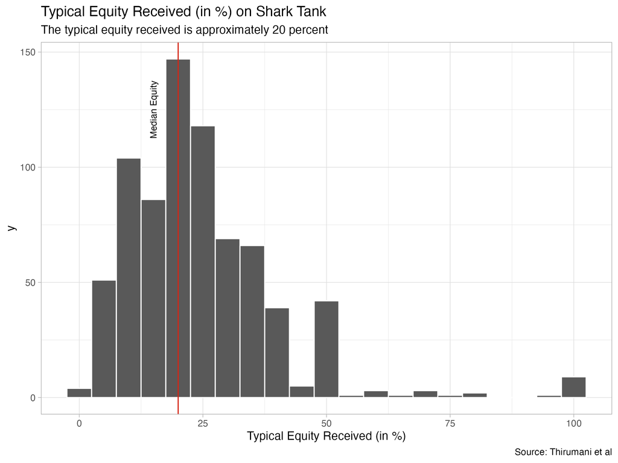

Perhaps it is an instance where female entrepreneurs ask for less and therefore receive less?

## References — if needed

Thirumani, S., Rehman, A.U., and Molagoda, J., 2023, Shark Tank US dataset, https://www.kaggle.com/datasets/thirumani/shark-tank-us-dataset